# Part 1: Non-SMI (PMS 2007 Analysis)

M K Jamieson

```r
# load libraries
pacman::p_load(skimr,
               gtsummary,
               finalfit,
               knitr,
               tidyverse,
               haven,
               ggplot2,
               forcats,
               janitor)
```

# 1 Introduction

This RMD will cover the selection, cleaning and exploration of the basic demographic maeup of the 2007 PMS survey set, as well as the exploration of ‘Common Mental Disorders’ (SMD) amoung respondants. The prevalance of ‘Severe Mental Illness’ (SMI), will be covered in another document.

## 1.1 Load Source Data

```r
# Read in 2007
source_pms07 <- haven::read_sav("pms07.sav",
                                user_na = TRUE) %>%
  as_factor()
```

## 1.2 Subset Variables of Interest

```r
# Variables of interest subset 2007
subset_pms07 <- source_pms07 %>%
  dplyr::select("pserial","trtment","eqvinc5","diag","CISRFOUR","ResSex","Health6","Language","Age10yr",
                "Age20yr","ETHNIC5","Origin","EDQUAL5","AnyQuals",
                "HiQuals","ResMarDF",
                "DVILO4a","DVPrac","Care1","Care2","Care3","Care4",
                "Care5","Everwk","yearjbl","JbReas","Looked",
                "YInAct","LookStop","LookSto2","Stat","Solo",
                "HrsWeek","PTWkHour","EmpStY","LookNot1","LookNot2",
                "LookNot3","DVLastWk","NotWk","WkShel1","HrsWork",
                "LookSto3","DiffJob","WkShel2","WkShel3","SEmpStY",
                "LookNow","LookAtAl","JobstM","EmpNo","Manage",
                "FtPtWk","NotWk","SEG","SC","SrcInc1","SrcInc2",
                "SrcInc3","SrcInc4","SrcInc5","SrcInc6","Gross4",
                "Gross4a","Ten1","LLord","SF6","SF7","SF9","SF11",
                "SF12","CONHOMD","IMon","FollUpGrp",
                "eligible","Stage2","Origin","DVPrac","Care1","Care2",
                "Care3","Care4","Care5","Medic","CnslHav","CnslTak",
                "CnslLng","DocYear","DocPsyc","PMatNum","DocTalk",
                "DocWeeks","InWhy","OutWhy","DayY","DayWht1",
                "DayWht2","DayWht3","DayWht4","CC2aY",
                "CC2Y1","CC2Y2","CC2Y3","CC2Y5","CC2Y6","CC2Y7",
                "CC2Y8","CC2Y9","MentHos","Ten1","Gross4a","qimd",
                "gor06","newsha","SF1","Happy","tenure","newten",
                "hhdtype","DISsex","DISeth","DISrel","DISAge",
                "DISmen","DISphy",
                "DISsori","CISRFOUR","panic","GAD","madd","OCD",
                "phob","dep","neurotic","nosymp","numdis",
                "PTSDever","MajorT16","PTSDcom","PTSDPos",
                "suicthwk","suicthyr","suicthlf","DSHlife",
                "suicatwk","suicatyr","suicatlf","DSHtry","suihfri",
                "suihhos","suihcom","suihhel","suihoth","DSH5",
                "DSHharm","DSH9","DSH10","PsycProb","Psycdis",
                "Psycdis_wt","BPDPH2","bdpd_wt","ASPDPH2","aspd_wt",
                "DVADHD1","DVADHD2","DVADHD4","scoff2","EDImpact",
                "bmigp4","DVAudit1","AUDITgp","DRNKPROB","SADQCSC",
                "SADQGP","AUDSAD2","Cannever","Cannyear","AMPHEVER",
                "AMPHYEAR","COCAEVER","CRACEVER","CRACYEAR",
                "ECSTEVER","ECSTYEAR","HEROEVER","HEROYEAR",
                "ACIDEVER","ACIDYEAR","MUSHEVER","MUSHYEAR",
                "METHEVER","METHYEAR","TRANEVER","TRANYEAR",
                "AMYLEVER","AMYLYEAR","ANABEVER",
                "ANABYEAR","GLUEEVER","GLUEYEAR","DRUGEVER",
                "DRUGYEAR","DRUGDEP",
                "DRUGDEP2","GamYR","dsmscgr","dsmprob","dsmpath",
                "numdiag","numdiag4","LCA","cluster1","cluster2",
                "cluster3","cluster4","cluster5","cluster6",
                "MedPsyc","MedDep","MedHyp","MedAnx","MedADHD",
                "anymed","Doc2Wks","DocPsyc","INQTRMEN","OUTQTRME",
                "PSYCTHER","COGTHER","ARTTHER","SOCTRAIN","MARITHER"
                ,"SEXTHER","COUNSEL","OTHTHER","OTHTHER","anyther",
                "trtment","DAYCOMYR","PSYTRTYR","PSYLGTYR",
                "CPNYR","CLDNYR","OTHNSEYR","SOCWRKYR","CPNYR",
                "ERI3","SFQA","SFQB","SFQC","SFQD",
                "SFQE","SFQF","SFQG","SFQH","DLSS4","DLSS5",
                "PrimGrp","ChldInst","LACare","BothMaPa",
                "YNotBoth","MaOrPa","AnyChild","NoChild",
                "InDebt1","InDebt6",
                "SFHELPYR","HMHELPYR","OREACHYR","anyccar","anyhlca"
                ,"anydaca","wt_ints1","ipsu_0714","istrata_0714","eqvinc5") %>%
  janitor::clean_names() %>%
  janitor::remove_empty("cols") %>%
  janitor::remove_empty("rows")


# Arrange alphabetically and make 'colnames' lowercase

subset_pms07 <-subset_pms07[,order(colnames(subset_pms07))] %>% rename_all(tolower)

# Check names
head(subset_pms07)
```

| acidever | acidyear | age10yr | age20yr | amphever | amphyear | amylever | amylyear | anabever | anabyear | any_child | any_quals | anyccar | anydaca | anyhlca | anymed | anyther | artther | aspd_wt | aspdph2 | audi_tgp | audsad2 | bdpd_wt | bmigp4 | both_ma_pa | bpdph2 | cannever | cannyear | care1 | care2 | … |
| --- | --- | --- | --- | --- | --- | --- | --- | --- | --- | --- | --- | --- | --- | --- | --- | --- | --- | --- | --- | --- | --- | --- | --- | --- | --- | --- | --- | --- | --- | --- |
| No | No | 45 - 54 | 35 - 54 | No | No | No | No | No | No | No | No | No | No | No | No | No | No | 1.20312857714106 | Negative - screened out due to phase one score | Score: 0-7 | No hazardous alcohol use | 1.20312857714106 | 18.5 to less than 25 | Yes | Negative - screened out due to phase one score | No | No | No | Item not applicable | … |
| No | No | 75+ | 75+ | No | No | No | No | No | No | No | No | No | No | No | No | No | No | 0.778035341931277 | Negative - screened out due to phase one score | Score: 0-7 | No hazardous alcohol use | 0.778035341931277 | 30 or more | Yes | Negative - screened out due to phase one score | No | No | No | Item not applicable | … |
| No | No | 45 - 54 | 35 - 54 | No | No | No | No | No | No | No | Yes | No | No | Yes | No | No | No | 0.601564288561244 | Negative - screened out due to phase two assessment | Score: 0-7 | No hazardous alcohol use | 3.62539799264465 | 25 to less than 30 | Yes | Negative - screened out due to phase two assessment | No | No | No | Item not applicable | … |
| No | No | 55 - 64 | 55 - 74 | No | No | No | No | No | No | Yes | Yes | No | No | No | No | No | No | 1.0860809062829 | Negative - screened out due to phase one score | Score: 0-7 | No hazardous alcohol use | 1.0860809062829 | 18.5 to less than 25 | Yes | Negative - screened out due to phase one score | No | No | No | Item not applicable | … |
| No | No | 65 - 74 | 55 - 74 | No | No | No | No | No | No | No | Yes | No | No | No | No | No | No | 0.659169354486047 | Negative - screened out due to phase one score | Score: 8-15 | No hazardous alcohol use | 0.659169354486047 | 25 to less than 30 | Yes | Negative - screened out due to phase one score | No | No | No | Item not applicable | … |
| No | No | 75+ | 75+ | No | No | No | No | No | No | Yes | No | No | No | Yes | No | No | No | 1.12523860269671 | Negative - screened out due to phase one score | Score: 0-7 | No hazardous alcohol use | 1.12523860269671 | 18.5 to less than 25 | Yes | Negative - screened out due to phase one score | No | No | No | Item not applicable | … |

```r
#skim(subset_pms07)
```

## 1.3 Cleaning Variables for Visulisation

```r
# Variable Cleanup
# diag var collapse  - works

cmdgroup <- fct_collapse(subset_pms07$diag,
    "MixedA&D" = c("MAD"),
    GAD = c("GAD"),
    Depression = c("sev dep ep", "mod dep ep", "mild dep ep"),
    Phobia = c("social phob", "Agoraphob", "Spec iso phob"),
    OCD = c("OCD"),
    Panic = c("panic"),
    NULL = c("No disord"))

# Age10yrs
age10yrs <- fct_collapse(subset_pms07$age10yr,
                         "16 to 24" = c("16 - 24"),
                         "25 to 34" = c("25 - 34"),
                         "35 to 44" = c("35 - 44"),
                         "45 to 54" = c("45 - 54"),
                         "55 to 64" = c("55 - 64"),
                         "65 to 74" = c("65 - 74"),
                         "75+" = c("75+"),
                         NULL = c("No answer/refused","Don't
                                  know","Missing data",
                                  "Proxy","Item not applicable"))
# Res_sex
sex <- fct_collapse(subset_pms07$res_sex,
                    Male = c("Male"),
                    Female = c("Female"),
                    NULL = c("No answer/refused","Don't know",
                             "Missing data",
                             "Proxy","Item not applicable"))


treatment <- fct_collapse(subset_pms07$trtment,
                          NULL = c("No answer/refused","Don't know","Missing data","Proxy","Item not applicable"),
                          Medication = c("medication only"),
                          Counselling = c("counselling only"),
                          None = c("no treatment"),
                          Both = c("both medication and counselling"))


employstat <- fct_collapse(subset_pms07$dvilo4a,
                            "Employed" = c("In employment not unpaid family worker"),
                            "Unpaid Family Work" = c("Unpaid family worker"),
                            "Unemployed" = c("Unemployed"),
                            "Economically inactive" = c("Economically inactive"),
                           NULL = c("No answer/refused","Don't know","Missing data","Proxy","Item not applicable"))

hiqual <- fct_collapse(subset_pms07$edqual5,
                           "Degree" = c("Degree"),
                           "Teaching, HND, Nursing" = c("Teaching, HND, nursing"),
                           "A Level" = c("A Level"),
                           "GCSE or equivalent" = c("GCSE or equivalent"),
                           "Foreign or other" = c("Foreign/other"),
                           "None" = c("No qualifications"),
                           NULL = c("No answer/refused","Don't know","Missing data","Proxy","Item not applicable"))

ethnicgrp <- fct_collapse(subset_pms07$ethnic5,
                                 "White British" = c("White British"),
                                 "White non British" = c("White non British"),
                                 "Black" = c("Black"),
                                 "South Asian" = c("South Asian (Indian, Pakistani or Bangladeshi)"),
                                 "Mixed or other" = c("Mixed or other"),
                                 NULL = c("No answer/refused","Don't know","Missing data","Proxy","Item not applicable"))

maritalstat <- fct_collapse(subset_pms07$res_mar_df,
                          "Married" = c("Married"),
                          "Cohabiting" = c("Cohabiting"),
                          "Single" = c("Single"),
                          "Widowed" = c("Widowed"),
                          "Divorced" = c("Divorced"),
                          "Separated" = c("Separated"),
                          NULL = c("No answer/refused","Don't know","Missing data","Proxy","Item not applicable"))


eqhouseinc <- fct_collapse(subset_pms07$eqvinc5,
                           "Highest" = c("highest quintile (>=?40,384)"),
                           "2nd" = c("2nd quintile (>=?24, 700 <?40,384)"),
                           "3rd" = c("3rd quintile (>=16,195 <?24,700)"),
                           "4th" = c("4th quintile (>=?10,575 <?16,195)"),
                           "Lowest" = c("Lowest quintile (<?10,575)"),
                           NULL = c("No answer/refused","Don't know","Missing data","Proxy","Item not applicable"))

region <- fct_collapse(subset_pms07$gor06,
                       "North East" = c("North East"),
                       "North West" = c("North West"),
                       "Yorkshire & The Humber" = c("Yorkshire & The Humber"),
                       "East Midlands" = c("East Midlands"),
                       "West Midlands" = c("West Midlands"),
                       "East of England" = c("East of England"),
                       "London" = c("London"),
                       "South West" = c("South West"),
                       "South East" = c("South East"),
                       NULL = c("No answer/refused","Don't know","Missing data","Proxy","Item not applicable"))

numcmd <- fct_collapse(subset_pms07$numdis,
                       "None" = c("None"),
                       "One" = c("One"),
                       "Two or more" = c("Two or more"),
                       NULL = c("No answer/refused","Don't know","Missing data","Proxy","Item not applicable"))

commcareyr <- fct_collapse(subset_pms07$cc2a_y,
                           "Yes" = c("Yes"),
                           "No" = c("No"),
                           NULL = c("No answer/refused","Don't know","Missing data","Schedule not applicable","Proxy","Item not applicable"))

table(commcareyr)
```

```
## commcareyr
##  Yes   No
##  597 6805
```

```r
evdrug <- fct_collapse(subset_pms07$drugever,
                           "Yes" = c("Yes"),
                           "No" = c("No"),
                           NULL = c("No answer/refused","Don't know","Missing data","Schedule not applicable","Proxy","Item not applicable"))


#all meds into 1 variable
#psychmed <- unite(subset_pms07, med_dep, med_hyp, med_anx, med_adhd, med_psyc, sep = "_", remove = TRUE, na.rm = FALSE)

subset_pms07 <- cbind(subset_pms07, evdrug, age10yrs, cmdgroup, commcareyr, employstat, eqhouseinc, ethnicgrp, hiqual, maritalstat, numcmd, region, sex, treatment)

subset_pms07 <-subset_pms07[,order(colnames(subset_pms07))] %>% rename_all(tolower)
```

# 2 Univariate Exploration

Quick look at each variable on its own to begin with.

## 2.1 Age

The majortiy of respondants were in the 35 to 44 age group (19.087%),and would also be considered ‘working age’.

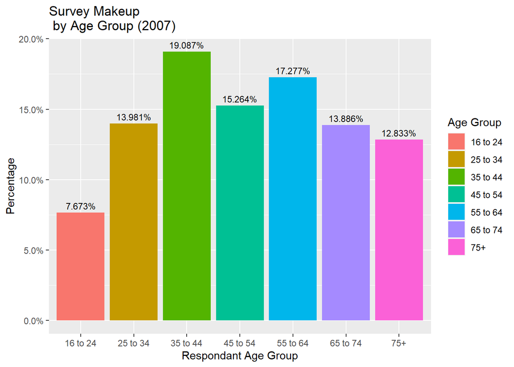

```r
# Age
ggplot(data = subset_pms07, aes(x = age10yrs,
                          y = prop.table(stat(count)),
                          fill = age10yrs,
                          label = scales::percent(prop.table(stat(count))))) +
    geom_bar() +
    geom_text(stat = 'count',
              position = position_dodge(.9),
              vjust = -0.5,
              size = 3) +
    scale_y_continuous(labels = scales::percent) +
    labs(title="Survey Makeup \n by Age Group (2007)",
       x = 'Respondant Age Group',
       y = 'Percentage', fill = 'Age Group')
```

## 2.2 Common Mental Disorders (CMD)

Althought the majority of Phase 1 respondants indicated they had no CMDs (82.7%), the most common indicated condition was Mixed Anxiety and Depression (8.6%), followed by Depression (3.4%).

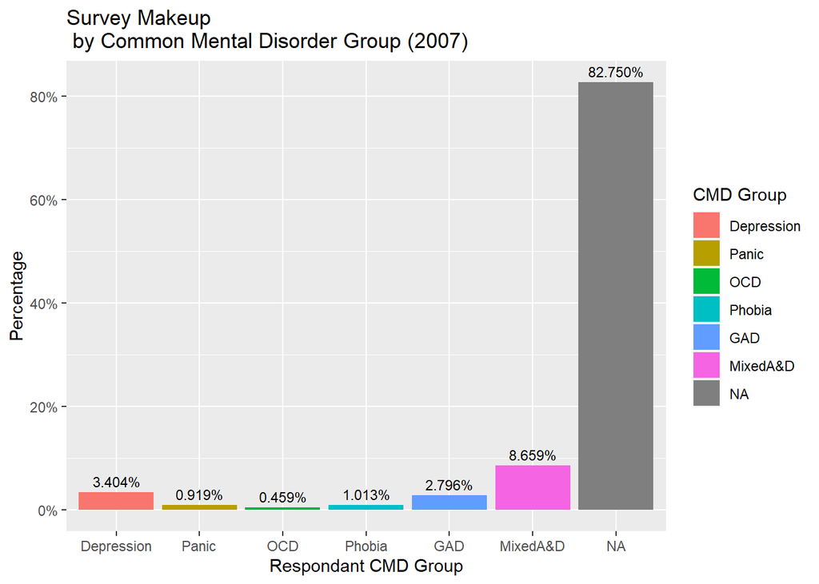

```r
# Common Mental Disorder Groups
ggplot(data = subset_pms07, aes(x = cmdgroup,
                          y = prop.table(stat(count)),
                          fill = cmdgroup,
                          label = scales::percent(prop.table(stat(count))))) +
    geom_bar() +
    geom_text(stat = 'count',
              position = position_dodge(.9),
              vjust = -0.5,
              size = 3) +
    scale_y_continuous(labels = scales::percent) +
    labs(title="Survey Makeup \n by Common Mental Disorder Group (2007)",
       x = 'Respondant CMD Group',
       y = 'Percentage', fill = 'CMD Group')
```